## [Part1] read.csv로 한글이 있는 자료 open

- df=read.csv('./DataSet/cust_order_data.csv',sep='\t',encoding='ANSI')
  - \t는 tab으로 분리된 자료를 의미함
  - encoding='ANSI'은 생략가능하나 컴퓨터 세팅에 따라 명시해야 하는 경우도 있음.

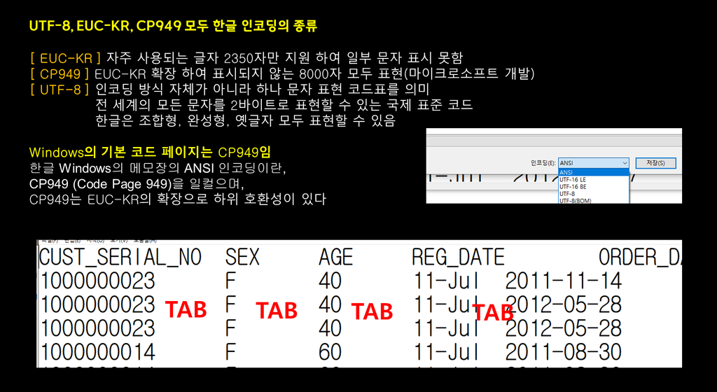

- 참고: http://aispiration.com/comp_document/regex-encoding.html
- 구글검색 'R 한글 깨짐' or 'R에서 한글 encoding'

### [미션. 1-1] 데이터 읽기전 메모리 모두 제거

```r
## --- [코드작성]메모리 제거
```

```r
## --- [코드작성] 메모리에 있는 변수 확인(메모리 제거가 잘 되었는지 확인용)
```

```r
df=read.csv('./DataSet/cust_order_data.csv',sep='\t',encoding='ANSI')
```

### [미션. 1-2] 총데이터의 갯수와 변수 성격 확인

```r
## --- [코드작성] 총데이터의 갯수 (행과 열의 갯수 확인)
```

```r
## --- [코드작성] 각 변수의 성격확인(character, factor, num, int등)
# https://rsas.tistory.com/229   (팩터와 levels 에 관한 설명)
```

```r
## --- [코드작성] 위로 3개의 자료만 읽기
```

```r
## --- [코드작성] 변수명(필드명)만 출력
```

### [미션. 1-3] 아래의 2개 변수(필드)외에 나머지 변수에 대하여 해석

- CUST_SERIAL_NO: 고객번호 / SEX: 고객성별

## [Part2] 자료 오류 확인

- 자료(데이터) 오류(데이터품질): 각 필드별로 불필요한 자료셋이 포함되어 있는지를 확인하여 봄
  - 아래의 데이터 구조 출력물에서도 쉽게 자료 오류를 확인할 수 있음

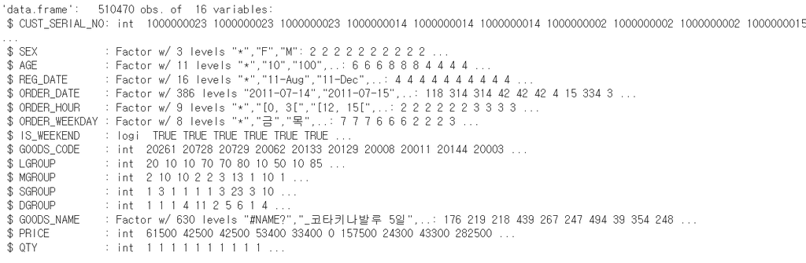

### [미션. 2-1] 결측치 확인 (참고R교재 33p-34p)

- 결측치에 대한 개념 이해
- R에서 결측치 처리에 대한 검색
- https://rfriend.tistory.com/34

```r
#---[코드작성] df의 전체 결측치 갯수 확인  (참고교재 33p)
```

```r
#---[코드작성] 각 변수별 결측치 갯수 확인 (참고교재 33p)
```

### [미션. 2-2] 결측치 활용법 (참고교재 P35)

- 일정한 값을 결측치로 변경하고 결측치 제거 명령어를 이용하여 행을 제거하기도 함.
- Size<-data$sizeOfsite  
  -자료의 일정변수를 Size 변수에 할당
- Size [Size>10000]<-NA  
  -Size값이 >10000 이상인 자료는 NA로 할당
- Size<-Size[complete.cases(Size)]  
  -NA가 있는 값 제거

```r
# GOODS_NAME값의 '#NAME?'를 NA로 대체하고 제거 하귀 위하여

# ---[코드작성]  df$GOODS_NAME을 summary 하여서 #NAME?가 있는지를 확인하여 봄
```

```r
#--- [코드작성] df$GOODS_NAME 에 자료가 '#NAME?' 인 자료만 subset으로 추출하여서 제거해도 되는 자료인지 확인하여 봄
#--- 참고교재  38p
```

```r
#--- df$GOODS_NAME의 '#NAME?' 인 자료를 'NA' 로 변환하기전

#-- [코드작성] df$GOODS_NAME 의 NA갯수 확인   (참고교재 32p의 2번)
```

```r
# --[코드작성] df$GOODS_NAME의 값이 #NAME?  인 자료에 NA값 할당
# 참고교재 35p


#-- [코드작성] df$GOODS_NAME 의 NA갯수 확인   (참고교재 32p의 2번)
```

```r
# -- [코드작성] 결측치 시각화
# 구글검색 'R 결측치 시각화' : 이미지로 검색하면 빠름
# https://m.blog.naver.com/PostView.naver?isHttpsRedirect=true&blogId=woosa7&logNo=220811391085
```

```r
# ---- NA가 있는 자료 제거
df=df[complete.cases(df),]

# ---- #NAME? 라는 글자가 있는지 갯수 확인
nrow(subset(df,df$GOODS_NAME=='#NAME?'))

# ---- [코드작성] 결측치 시각화를 통해 NA값이 모두 제거 되었는지 확인
```

0

## [factor의 요인값 제거하여도 levels 값은 변경되지 않음. ]

- str(df) 를 수행하여 보면 여전히 GOODS_NAME levels 에 '#NAME?' 가 있음
- 레벨 제거 하기 위하여서 패키지를 사용해야함
- 구글검색 ' R 레벨 제거'
- http://aispiration.com/data-science/ds-factor-stat545.html
- 쉽게 하는 방법은 charater로 형변한후 다시 factor로 변환하면 됨

```r
str(df)   # 자료보면 14번 열의 GOODS_NAME에 #NAME? 존재함.
class(df[,14])    # factor로 나옴
df[,14]=factor(as.character(df[,14]))  # 문자열로 변경후 다시 factor함.(factor은 필요하면 함)
class(df[,14])  # 확인해보면 다시 factor 되어 있음
str(df)   # df[,14] 에 #NAME? 없어짐
```

```
'data.frame':	508347 obs. of  16 variables:
 $ CUST_SERIAL_NO: int  1000000023 1000000023 1000000023 1000000014 1000000014 1000000014 1000000002 1000000002 1000000002 1000000015 ...
 $ SEX           : Factor w/ 3 levels "*","F","M": 2 2 2 2 2 2 2 2 2 2 ...
 $ AGE           : Factor w/ 11 levels "*","10","100",..: 6 6 6 8 8 8 4 4 4 4 ...
 $ REG_DATE      : Factor w/ 16 levels "*","11-Aug","11-Dec",..: 4 4 4 4 4 4 4 4 4 4 ...
 $ ORDER_DATE    : Factor w/ 386 levels "2011-07-14","2011-07-15",..: 118 314 314 42 42 42 4 15 334 3 ...
 $ ORDER_HOUR    : Factor w/ 9 levels "*","[0, 3[","[12, 15[",..: 2 2 2 2 2 2 3 3 3 3 ...
 $ ORDER_WEEKDAY : Factor w/ 8 levels "*","금","목",..: 7 7 7 6 6 6 2 2 2 3 ...
 $ IS_WEEKEND    : logi  TRUE TRUE TRUE TRUE TRUE TRUE ...
 $ GOODS_CODE    : int  20261 20728 20729 20062 20133 20129 20008 20011 20144 20003 ...
 $ LGROUP        : int  20 10 10 70 70 80 10 50 10 85 ...
 $ MGROUP        : int  2 10 10 2 2 3 13 1 10 1 ...
 $ SGROUP        : int  1 3 1 1 1 1 3 23 3 10 ...
 $ DGROUP        : int  1 1 1 4 11 2 5 6 1 4 ...
 $ GOODS_NAME    : Factor w/ 630 levels "#NAME?","_코타키나발루 5일",..: 176 219 218 439 267 247 494 39 354 248 ...
 $ PRICE         : int  61500 42500 42500 53400 33400 0 157500 24300 43300 282500 ...
 $ QTY           : int  1 1 1 1 1 1 1 1 1 1 ...
```

'factor'

'factor'

```
'data.frame':	508347 obs. of  16 variables:
 $ CUST_SERIAL_NO: int  1000000023 1000000023 1000000023 1000000014 1000000014 1000000014 1000000002 1000000002 1000000002 1000000015 ...
 $ SEX           : Factor w/ 3 levels "*","F","M": 2 2 2 2 2 2 2 2 2 2 ...
 $ AGE           : Factor w/ 11 levels "*","10","100",..: 6 6 6 8 8 8 4 4 4 4 ...
 $ REG_DATE      : Factor w/ 16 levels "*","11-Aug","11-Dec",..: 4 4 4 4 4 4 4 4 4 4 ...
 $ ORDER_DATE    : Factor w/ 386 levels "2011-07-14","2011-07-15",..: 118 314 314 42 42 42 4 15 334 3 ...
 $ ORDER_HOUR    : Factor w/ 9 levels "*","[0, 3[","[12, 15[",..: 2 2 2 2 2 2 3 3 3 3 ...
 $ ORDER_WEEKDAY : Factor w/ 8 levels "*","금","목",..: 7 7 7 6 6 6 2 2 2 3 ...
 $ IS_WEEKEND    : logi  TRUE TRUE TRUE TRUE TRUE TRUE ...
 $ GOODS_CODE    : int  20261 20728 20729 20062 20133 20129 20008 20011 20144 20003 ...
 $ LGROUP        : int  20 10 10 70 70 80 10 50 10 85 ...
 $ MGROUP        : int  2 10 10 2 2 3 13 1 10 1 ...
 $ SGROUP        : int  1 3 1 1 1 1 3 23 3 10 ...
 $ DGROUP        : int  1 1 1 4 11 2 5 6 1 4 ...
 $ GOODS_NAME    : Factor w/ 629 levels "_코타키나발루 5일",..: 175 218 217 438 266 246 493 38 353 247 ...
 $ PRICE         : int  61500 42500 42500 53400 33400 0 157500 24300 43300 282500 ...
 $ QTY           : int  1 1 1 1 1 1 1 1 1 1 ...
```

## [ df의 모든 factor를 character로 변경하고자함]

- 아래는 GOODS_NAMES의 #NAME? 를 제거하기 전 자료임
- 아래 자료에 보면 * 표시는 #NAME? 를 제거한 작업을 했을때 일부분은 삭제됨

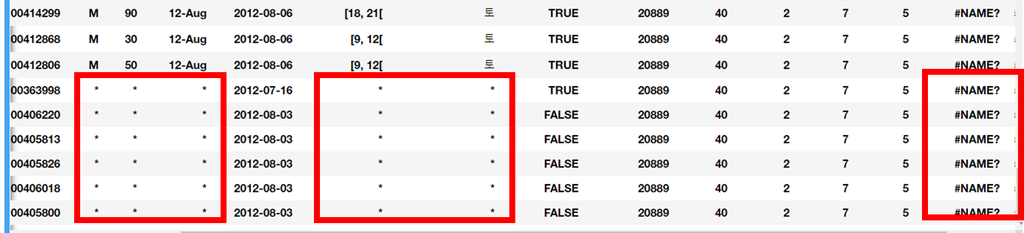

- 하지만 str(df)를 해보면 여전히 AGE등에 levels로 * 표시가 남아있음
  - 이경우는 * 이 모두 제거되었지만 levels에 남아있거나 (character후 다시 factor로 변환하면 확인됨)
  - '*' 이 있는 자료가 실제 남아 있는 경우(unique로 확인해보면됨)
- levels 값의 변화를 위해
- 모든 factor형을 character로 변환하여 levels를 조정하여 확인하고자함.
- 참고 type확인: class(df[,1])

```r
# 구글 검색  R에서 if
cnt=length(df)

for (i in 1:cnt) {
    if (class(df[,i])=='factor'){
        df[,i]=as.character(df[,i])
        }
}
str(df)
```

[output not shown]

```r
# 다시 factor로 변환해서도 levels에 '*' 이 있는 경우는 unique로 '*' 표시가 실제 있다는 뜻
cnt=length(df)

for (i in 1:cnt) {
    if (class(df[,i])=='character'){
        df[,i]=as.factor(df[,i])
        }
}
str(df)
```

[output not shown]

```r
## 위의 자료 형 변환전에 이 과정을 먼저 진행해도 됨
## 자료값에 실제로 '*' 이 있음이 확인됨
colNum=c(2,3,4,6,7)
for (i in colNum){
    print(paste('---------------', i, '번째컬럼: 컬럼명은 ', names(df)[i]))
    print(unique(df[,i]))
    cat('\n')    # 한줄 띄는 명령어는 cat으로 사용해야함.
       #https://m.blog.naver.com/PostView.naver?isHttpsRedirect=true&blogId=dic1224&logNo=80206919335
}
```

```
[1] "--------------- 2 번째컬럼: 컬럼명은  SEX"
[1] "F" "M" "*"

[1] "--------------- 3 번째컬럼: 컬럼명은  AGE"
 [1] "40"  "60"  "20"  "30"  "50"  "70"  "80"  "90"  "10"  "100" "*"

[1] "--------------- 4 번째컬럼: 컬럼명은  REG_DATE"
 [1] "11-Jul" "11-Aug" "11-Sep" "11-Oct" "11-Nov" "11-Dec" "12-Jan" "12-Feb"
 [9] "12-Mar" "12-Apr" "12-May" "12-Jun" "12-Jul" "12-Aug" "11-Jun" "*"

[1] "--------------- 6 번째컬럼: 컬럼명은  ORDER_HOUR"
[1] "[0, 3["   "[12, 15[" "[15, 18[" "[18, 21[" "[21, 24[" "[6, 9["   "[9, 12["
[8] "[3, 6["   "*"

[1] "--------------- 7 번째컬럼: 컬럼명은  ORDER_WEEKDAY"
[1] "토" "일" "금" "목" "수" "화" "월" "*"
```

```r
## '*' 이 있는 자료 제거는
# 방법1: '*' 표시가 있는 자료를 NA로 변경하고, NA값 제거
# 방법2: '*' 표시가 없는 자료만 다시 별도로 제작
# 여기서는 방법2로 작업

df2=subset(df,df[,2]!='*')
colNum=c(2,3,4,6,7)
for (i in colNum){
    print(paste('---------------', i, '번째컬럼: 컬럼명은 ', names(df)[i]))
    print(unique(df2[,i]))
    cat('\n')    # 한줄 띄는 명령어는 cat으로 사용해야함.
       #https://m.blog.naver.com/PostView.naver?isHttpsRedirect=true&blogId=dic1224&logNo=80206919335
}
```

```
[1] "--------------- 2 번째컬럼: 컬럼명은  SEX"
[1] "F" "M"

[1] "--------------- 3 번째컬럼: 컬럼명은  AGE"
 [1] "40"  "60"  "20"  "30"  "50"  "70"  "80"  "90"  "10"  "100"

[1] "--------------- 4 번째컬럼: 컬럼명은  REG_DATE"
 [1] "11-Jul" "11-Aug" "11-Sep" "11-Oct" "11-Nov" "11-Dec" "12-Jan" "12-Feb"
 [9] "12-Mar" "12-Apr" "12-May" "12-Jun" "12-Jul" "12-Aug" "11-Jun"

[1] "--------------- 6 번째컬럼: 컬럼명은  ORDER_HOUR"
[1] "[0, 3["   "[12, 15[" "[15, 18[" "[18, 21[" "[21, 24[" "[6, 9["   "[9, 12["
[8] "[3, 6["

[1] "--------------- 7 번째컬럼: 컬럼명은  ORDER_WEEKDAY"
[1] "토" "일" "금" "목" "수" "화" "월"
```

## [Part3] 문자 자료 날짜자료로 변환후 파생변후(년,월,요일등제작)

- ORDER_DATE 변수(필드)를 chr 또는 factor에서 Date로 형변환
- Date로 형 변환되면 년, 월, 일, 요일등을 쉽게 제작할수 있음

### [미션. 3-1] 형변환

```r
## -[코드제작]  df2$ORDER_DATE 필드를 날짜형식으로 변경하여 tmp  변수에 할당하여 class로 type 확인
#  구글검색 ' R에서 문자자료 날짜 변환'
```

```r
## -[코드제작]    df2$ORDER_DATE에 tmp 자료 할당


## -[코드제작]  데이터 구조확인하여서 ORDER_DATE 에 Date 나오는지 확인
```

## [미션. 3-2] Date 형식 자료 년,월,일,요일 제작

- lubridate 패키지를 설치한뒤, 도움말 또는 구글검색
- year, month 파생변수 제작 (요일은 ORDER_WEEKDAY 에 있음)

```r
install.packages("lubridate")
library(lubridate)
```

```r
df2$year=year(df2$ORDER_DATE)
df2$month=month(df2$ORDER_DATE)

head(df2)
```

A data.frame: 6 × 18

| CUST_SERIAL_NO <int> | SEX <chr> | AGE <chr> | REG_DATE <chr> | ORDER_DATE <date> | ORDER_HOUR <chr> | ORDER_WEEKDAY <chr> | IS_WEEKEND <lgl> | GOODS_CODE <int> | LGROUP <int> | MGROUP <int> | SGROUP <int> | DGROUP <int> | GOODS_NAME <chr> | PRICE <int> | QTY <int> | year <dbl> | month <dbl> |
| --- | --- | --- | --- | --- | --- | --- | --- | --- | --- | --- | --- | --- | --- | --- | --- | --- | --- |
| 1000000023 | F | 40 | 11-Jul | 2011-11-14 | [0, 3[ | 토 | TRUE | 20261 | 20 | 2 | 1 | 1 | 더무료체험 | 61500 | 1 | 2011 | 11 |
| 1000000023 | F | 40 | 11-Jul | 2012-05-28 | [0, 3[ | 토 | TRUE | 20728 | 10 | 10 | 3 | 1 | 메쉬런닝화 + 슈즈 2종 여성 | 42500 | 1 | 2012 | 5 |
| 1000000023 | F | 40 | 11-Jul | 2012-05-28 | [0, 3[ | 토 | TRUE | 20729 | 10 | 10 | 1 | 1 | 메쉬런닝화 + 슈즈 2종 남성 | 42500 | 1 | 2012 | 5 |
| 1000000014 | F | 60 | 11-Jul | 2011-08-30 | [0, 3[ | 일 | TRUE | 20062 | 70 | 2 | 1 | 4 | 왕만두 16봉 구성 +추가구성 참치 | 53400 | 1 | 2011 | 8 |
| 1000000014 | F | 60 | 11-Jul | 2011-08-30 | [0, 3[ | 일 | TRUE | 20133 | 70 | 2 | 1 | 11 | 베스트셀러 5종 | 33400 | 1 | 2011 | 8 |
| 1000000014 | F | 60 | 11-Jul | 2011-08-30 | [0, 3[ | 일 | TRUE | 20129 | 80 | 3 | 1 | 2 | 미서부 자연의 위대함 요세미티국립공원+4대캐년 일주 8일 | 0 | 1 | 2011 | 8 |

```r
str(df2)
```

```
'data.frame':	505235 obs. of  18 variables:
 $ CUST_SERIAL_NO: int  1000000023 1000000023 1000000023 1000000014 1000000014 1000000014 1000000002 1000000002 1000000002 1000000015 ...
 $ SEX           : chr  "F" "F" "F" "F" ...
 $ AGE           : chr  "40" "40" "40" "60" ...
 $ REG_DATE      : chr  "11-Jul" "11-Jul" "11-Jul" "11-Jul" ...
 $ ORDER_DATE    : Date, format: "2011-11-14" "2012-05-28" ...
 $ ORDER_HOUR    : chr  "[0, 3[" "[0, 3[" "[0, 3[" "[0, 3[" ...
 $ ORDER_WEEKDAY : chr  "토" "토" "토" "일" ...
 $ IS_WEEKEND    : logi  TRUE TRUE TRUE TRUE TRUE TRUE ...
 $ GOODS_CODE    : int  20261 20728 20729 20062 20133 20129 20008 20011 20144 20003 ...
 $ LGROUP        : int  20 10 10 70 70 80 10 50 10 85 ...
 $ MGROUP        : int  2 10 10 2 2 3 13 1 10 1 ...
 $ SGROUP        : int  1 3 1 1 1 1 3 23 3 10 ...
 $ DGROUP        : int  1 1 1 4 11 2 5 6 1 4 ...
 $ GOODS_NAME    : chr  "더무료체험" "메쉬런닝화 + 슈즈 2종 여성" "메쉬런닝화 +  슈즈 2종  남성" "왕만두 16봉 구성 +추가구성 참치" ...
 $ PRICE         : int  61500 42500 42500 53400 33400 0 157500 24300 43300 282500 ...
 $ QTY           : int  1 1 1 1 1 1 1 1 1 1 ...
 $ year          : num  2011 2012 2012 2011 2011 ...
 $ month         : num  11 5 5 8 8 8 7 7 6 7 ...
```

### [미션. 3-2] 성별의 F는 'female' / M은 'male'로 변환하여 새로운 gender 변수생성

- 참고교재 27p

```r
## - df2자료에서 다시한번더 확인
## --[코드제작] - unique명령으로 F,M만 존재하는지 확인
unique(df2[,2])
```

1. 'F'

2. 'M'

```r
#-- [코드제작] subset명령으로 df2[,2]자료에 '*'없음 확인
```

```r
#-- [코드제작] table 명령으로 F,M의 빈도수(도수분포) 계산
```

```r
# -- [코드제작] df$gender = ifelse 명령으로 F이면 'female',  그외는 male로 할당
## 참고 교재 27p



# 위로 6개의 자료 보기
```

## [Part5] 데이터셋 구성하여 저장

```r
# 성별구매건수
# - [코드제작] gender 변수에 할당 =>16:19번째의 열 컬럼만 별도로 구성하여서
```

```r
# --[코두제작]  tmp1에 성별,구매건수의 총합
# 참고교재 40p
```

```r
# --[코드제작] tmp2에 성별, 구매건수의 합의 비율
# 참고교재 41p
```

```r
# -

tmp3=rbind(tmp1,tmp2)
rownames(tmp3)=c('total','prop')
tmp3
```

A matrix: 2 × 2 of type dbl

|  | female | male |
| --- | --- | --- |
| total | 341342.00 | 193998.00 |
| prop | 63.76 | 36.24 |

```r
# 참고교재 41p
# --[코드제작]  tmp3의 행단위의 합
```

A matrix: 2 × 3 of type dbl

[output not shown]

```r
# --[코드제작]  tmp4에 월별 성별 빈도수(몇번 나왔나)
# 참고교재 41p
```

```
     female  male
  1   28296 13998
  2   25319 10374
  3   25980 11681
  4   35812 16555
  5   52465 28239
  6   42456 27817
  7   47570 36734
  8   18012 10029
  9    4838  1674
  10   3808  1188
  11  19157  8692
  12  21675 12866
```

```r
# -- 월별, 구매건수의 총합
tmp=split(gender.Qty$QTY, gender.Qty$month)
sapply(tmp,sum)
```

**1**

45019

**2**

37526

**3**

39396

**4**

54660

**5**

84512

**6**

74598

**7**

91087

**8**

30045

**9**

7038

**10**

5184

**11**

29693

**12**

36582